# Black Friday Sale Analysis

## INTRODUCTION

A retail company wants to understand the customer purchase behavior (specifically, purchase amount) against various products of different categories. They have shared purchase summary of various customers for a selected high-volume products from last month.

They want to build a model to predict the purchase amount of customer against various products which will help them to create personalized offer for customers against different products.

## PROBLEM STATEMENT

- To perform Exploratory Data Analysis on the given dataset.
- To identify the most important variables and to define the best regression model for predicting out target variable.

## **Predictors and Target Variable**

Considering Gender,Age,State,Furniture,Clothing,Electronics as the predictors that will influence more the amount spent by a customer on this day. While Purchase is target variable.

## Initializing Packages and Importing Data

```python
%matplotlib inline
import numpy as np
import pandas as pd
import matplotlib.pyplot as plt
import seaborn as sns
import os
from matplotlib import pyplot
import scipy.stats as stats
from scipy.stats import chisquare
sns.set(style='ticks', context='talk')
```

```python
#Kaggle already divides the dataset into test and train data.
d=pd.read_csv("train.csv")
test = pd.read_csv("test.csv")
```

## DATA

```python
d.head()
```

|  | User_ID | Product_ID | Gender | Age | Occupation | State | Stay_In_Current_City_Years | Marital_Status | Furniture | Clothing | Electronics | Purchase |
| --- | --- | --- | --- | --- | --- | --- | --- | --- | --- | --- | --- | --- |
| 0 | 1000001 | P00069042 | M | 0-17 | 10 | NJ | 2 | Single | 3 | NaN | NaN | 8370 |
| 1 | 1000001 | P00248942 | M | 0-17 | 10 | NJ | 2 | Single | 1 | 6.0 | 14.0 | 15200 |
| 2 | 1000001 | P00087842 | M | 0-17 | 10 | NJ | 2 | Single | 12 | NaN | NaN | 1422 |
| 3 | 1000001 | P00085442 | M | 0-17 | 10 | NJ | 2 | Single | 12 | 14.0 | NaN | 1057 |
| 4 | 1000002 | P00285442 | F | 55+ | 16 | CA | 4+ | Single | 8 | NaN | NaN | 7969 |

```python
test.State.isnull()
```

```
0         False
1         False
2         False
3         False
4         False
          ...
233594    False
233595    False
233596    False
233597    False
233598    False
Name: State, Length: 233599, dtype: bool
```

```python
d.info()
```

```
<class 'pandas.core.frame.DataFrame'>
RangeIndex: 550068 entries, 0 to 550067
Data columns (total 12 columns):
User_ID                       550068 non-null int64
Product_ID                    550068 non-null object
Gender                        550068 non-null object
Age                           550068 non-null object
Occupation                    550068 non-null int64
State                         550068 non-null object
Stay_In_Current_City_Years    550068 non-null object
Marital_Status                550068 non-null object
Furniture                     550068 non-null int64
Clothing                      376430 non-null float64
Electronics                   166821 non-null float64
Purchase                      550068 non-null int64
dtypes: float64(2), int64(4), object(6)
memory usage: 50.4+ MB
```

## DATA CLEANING

```python
d.fillna(value=0,inplace=True)
d.head()
```

|  | User_ID | Product_ID | Gender | Age | Occupation | State | Stay_In_Current_City_Years | Marital_Status | Furniture | Clothing | Electronics | Purchase |
| --- | --- | --- | --- | --- | --- | --- | --- | --- | --- | --- | --- | --- |
| 0 | 1000001 | P00069042 | M | 0-17 | 10 | NJ | 2 | Single | 3 | 0.0 | 0.0 | 8370 |
| 1 | 1000001 | P00248942 | M | 0-17 | 10 | NJ | 2 | Single | 1 | 6.0 | 14.0 | 15200 |
| 2 | 1000001 | P00087842 | M | 0-17 | 10 | NJ | 2 | Single | 12 | 0.0 | 0.0 | 1422 |
| 3 | 1000001 | P00085442 | M | 0-17 | 10 | NJ | 2 | Single | 12 | 14.0 | 0.0 | 1057 |
| 4 | 1000002 | P00285442 | F | 55+ | 16 | CA | 4+ | Single | 8 | 0.0 | 0.0 | 7969 |

```python
d.describe()
```

|  | User_ID | Occupation | Furniture | Clothing | Electronics | Purchase |
| --- | --- | --- | --- | --- | --- | --- |
| count | 5.500680e+05 | 550068.000000 | 550068.000000 | 550068.000000 | 550068.000000 | 550068.000000 |
| mean | 1.003029e+06 | 8.076707 | 5.404270 | 6.735436 | 3.841941 | 9263.968713 |
| std | 1.727592e+03 | 6.522660 | 3.936211 | 6.215492 | 6.250712 | 5023.065394 |
| min | 1.000001e+06 | 0.000000 | 1.000000 | 0.000000 | 0.000000 | 12.000000 |
| 25% | 1.001516e+06 | 2.000000 | 1.000000 | 0.000000 | 0.000000 | 5823.000000 |
| 50% | 1.003077e+06 | 7.000000 | 5.000000 | 5.000000 | 0.000000 | 8047.000000 |
| 75% | 1.004478e+06 | 14.000000 | 8.000000 | 14.000000 | 8.000000 | 12054.000000 |
| max | 1.006040e+06 | 20.000000 | 20.000000 | 18.000000 | 18.000000 | 23961.000000 |

## EXPLORATORY DATA ANALYSIS

**Distribution of the target variable:PURCHASE**

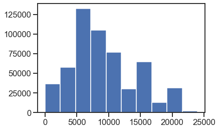

```python
plt.hist(d.Purchase)
```

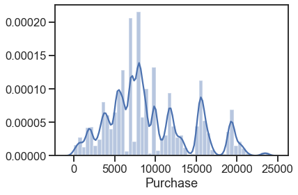

```python
sns.distplot(d['Purchase'])
```

```python
print ("Skew is:", d.Purchase.skew())
print("Kurtosis: %f" % d.Purchase.kurt())
```

```
Skew is: 0.6001400037087128
Kurtosis: -0.338378
```

**Distribution of the variable:GENDER**

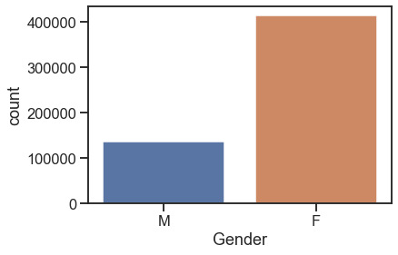

```python
# Countplot of Male and female(to compare the total count and the purchase done by the higher and
#the lower gender)
sns.countplot(x ='Gender', data = d)
```

There are more FEMALES buying products on Black Friday than MALE, but do they spend more?

**Distribution of the variable: AGE**

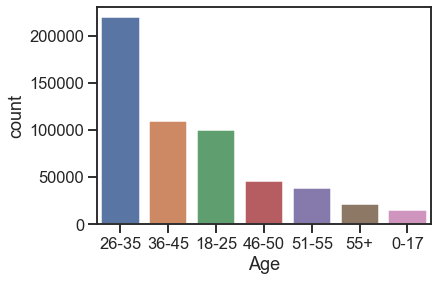

```python
# Bar chart for Age
ordr =d.groupby(["Age"]).count().sort_values(by='Purchase',ascending=False).index
sns.countplot(d['Age'], label=True, order=ordr)
```

As expected, most purchases are made by people between 18 to 45 years old.

**Distribution of the variable: Marital_Status**

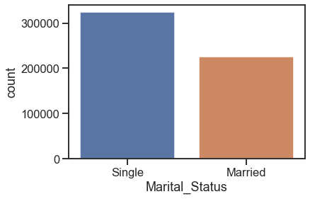

```python
sns.countplot(d.Marital_Status)
```

There are more single people products on Black Friday than married people, but do they spend more?

**Distribution of the variable: Stay_In_Current_City_Years**

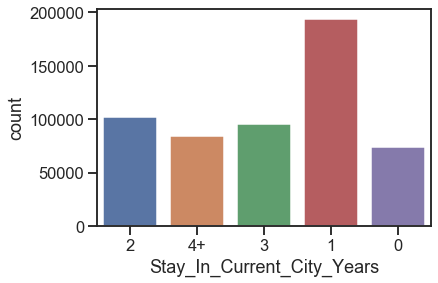

```python
sns.countplot(d.Stay_In_Current_City_Years)
```

The tendency looks like the longest somebody is living in that city the less inclined they are to purchase new things. Henceforth, in the event that somebody is new around the local area and requirements an extraordinary number of new things for their home that they'll exploit the low costs in Black Friday to buy every one of the things required.

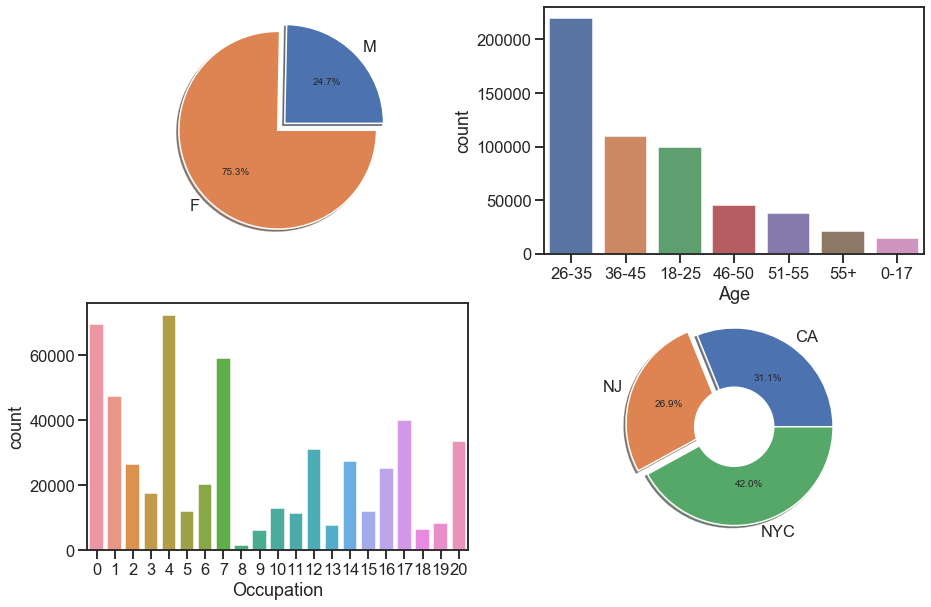

```python
plt.figure(figsize=(15,10))

# Pie chart for gender distribution
plt.subplot(2,2,1)
gender_count = [d.Gender[d['Gender']=='M'].count(),
                d.Gender[d['Gender']=='F'].count()]
gender_lab = d.Gender.unique()
expl = (0.1,0)
plt.pie(gender_count, labels=gender_lab, explode=expl, shadow=True , autopct='%1.1f%%');

# Bar chart for Age
plt.subplot(2,2,2)
ordr =d.groupby(["Age"]).count().sort_values(by='Purchase',ascending=False).index
sns.countplot(d['Age'], label=True, order=ordr)

# Bar chart for Occupation
plt.subplot(2,2,3)
sns.countplot(d.Occupation)

# Donut chart for State
plt.subplot(2,2,4)
city_group = d.groupby(["State"])
city_count = city_group[['Purchase']].count().values.tolist()
city_lab = d.groupby(["State"]).count().index.values
my_circle = plt.Circle( (0,0), 0.4, color='white')
expl1 = (0,0.1,0)
plt.pie(city_count, labels=city_lab,explode=expl1, shadow=True, autopct='%1.1f%%')
plt.gcf().gca().add_artist(my_circle)


plt.show()
```

```python
d1=d
```

```python
d1.head()
```

|  | User_ID | Product_ID | Gender | Age | Occupation | State | Stay_In_Current_City_Years | Marital_Status | Furniture | Clothing | Electronics | Purchase |
| --- | --- | --- | --- | --- | --- | --- | --- | --- | --- | --- | --- | --- |
| 0 | 1000001 | P00069042 | M | 0-17 | 10 | NJ | 2 | Single | 3 | 0.0 | 0.0 | 8370 |
| 1 | 1000001 | P00248942 | M | 0-17 | 10 | NJ | 2 | Single | 1 | 6.0 | 14.0 | 15200 |
| 2 | 1000001 | P00087842 | M | 0-17 | 10 | NJ | 2 | Single | 12 | 0.0 | 0.0 | 1422 |
| 3 | 1000001 | P00085442 | M | 0-17 | 10 | NJ | 2 | Single | 12 | 14.0 | 0.0 | 1057 |
| 4 | 1000002 | P00285442 | F | 55+ | 16 | CA | 4+ | Single | 8 | 0.0 | 0.0 | 7969 |

```python
d.Furniture.value_counts()
```

```
5     150933
1     140378
8     113925
11     24287
2      23864
6      20466
3      20213
4      11753
16      9828
15      6290
13      5549
10      5125
12      3947
7       3721
18      3125
20      2550
19      1603
14      1523
17       578
9        410
Name: Furniture, dtype: int64
```

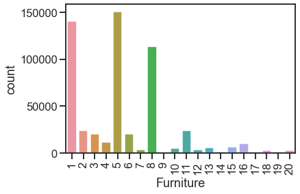

```python
sns.countplot(d.Furniture)
plt.xticks(rotation=90)
```

```python
d.Clothing.value_counts()
```

```
0.0     173638
8.0      64088
14.0     55108
2.0      49217
16.0     43255
15.0     37855
5.0      26235
4.0      25677
6.0      16466
11.0     14134
17.0     13320
13.0     10531
9.0       5693
12.0      5528
10.0      3043
3.0       2884
18.0      2770
7.0        626
Name: Clothing, dtype: int64
```

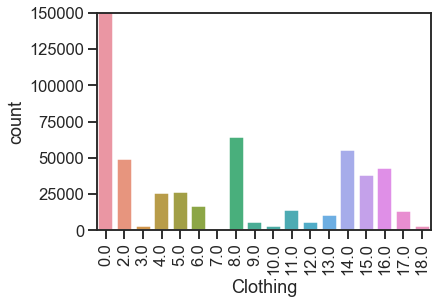

```python
sns.countplot(d.Clothing)
plt.ylim(0, 150000)
plt.xticks(rotation=90)
```

```python
d.Electronics.value_counts()
```

```
0.0     383247
16.0     32636
15.0     28013
14.0     18428
17.0     16702
5.0      16658
8.0      12562
9.0      11579
12.0      9246
13.0      5459
6.0       4890
18.0      4629
4.0       1875
11.0      1805
10.0      1726
3.0        613
Name: Electronics, dtype: int64
```

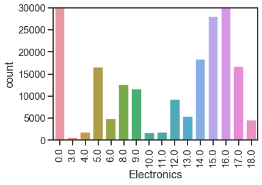

```python
sns.countplot(d.Electronics)
plt.ylim(0, 30000)
plt.xticks(rotation=90)
```

### Target Variable vs Predictor Analysis

**Gender,Marital Status and Purchase analysis**

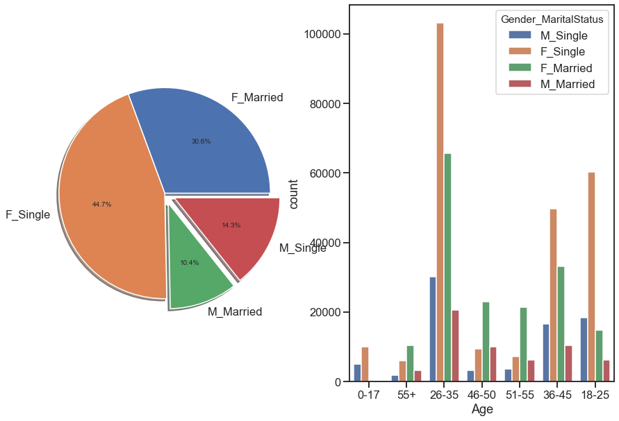

```python
import warnings
warnings.filterwarnings("ignore")
#Creating new column in the dataset
d1['Gender_MaritalStatus'] = d1.apply(lambda x:'%s_%s' % (x['Gender'],x['Marital_Status']),axis=1)


plt.figure(figsize=(15,10))

plt.subplot(1,2,1)
group_g_ms = d1.groupby(["Gender_MaritalStatus"])
count_ms = group_g_ms[['Purchase']].count().values.tolist()
lab1 = d1.groupby(["Gender_MaritalStatus"]).count().index.values
expl2 = (0,0,0.1,0.1)

plt.pie(count_ms, labels=lab1,explode=expl2, shadow=True, autopct='%1.1f%%')

plt.subplot(1,2,2)
sns.countplot(d1['Age'],hue=d1['Gender_MaritalStatus'])

plt.show()
```

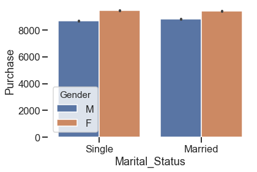

```python
sns.set_style('ticks')
sns.barplot(x='Marital_Status',y='Purchase',data = d,hue='Gender')
sns.despine(left=True,bottom=True)
```

**Age and Purchase Analysis**

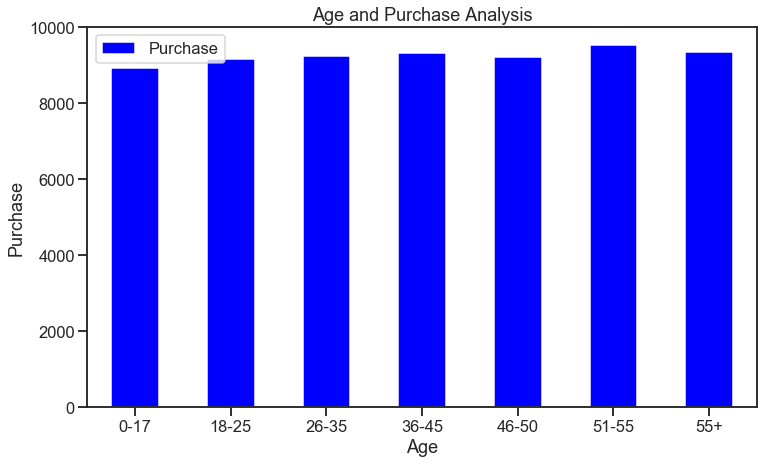

```python
Purchase_pivot = \
d.pivot_table(index='Age', values="Purchase", aggfunc=np.mean)

Purchase_pivot.plot(kind='bar', color='blue',figsize=(12,7))
plt.xlabel("Age")
plt.ylabel("Purchase")
plt.title("Age and Purchase Analysis")
plt.xticks(rotation=0)
plt.show()
```

Nevertheless, regarding the average spend by group age we can see the amount spent is almost the same for everyone.

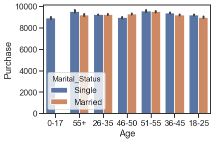

```python
#Barplot is used to check the purchase range by different age groups (which are further segregated
#by Marital status)

sns.barplot(x='Age',y='Purchase',data =d,hue='Marital_Status')
```

**State,Gender and Purchase Analysis**

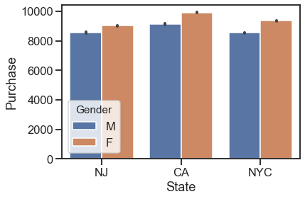

```python
sns.barplot(x = 'State', y = 'Purchase', data = d, hue = 'Gender')
```

Even though there are more buyers from NYC ,CA buyers spend most amount during the sale.

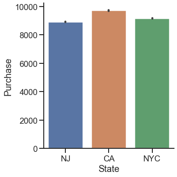

```python
sns.catplot(x = 'State', y = 'Purchase', data = d, kind = 'bar')
```

**Furniture and Purchase Analysis**

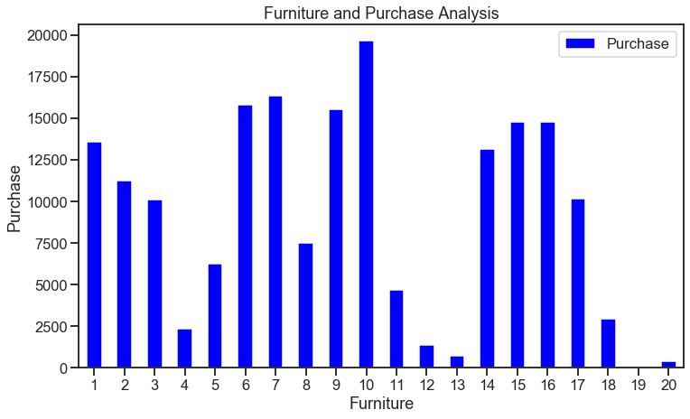

```python
Furniture_pivot = \
d.pivot_table(index='Furniture', values="Purchase", aggfunc=np.mean)

Furniture_pivot.plot(kind='bar', color='blue',figsize=(12,7))
plt.xlabel("Furniture")
plt.ylabel("Purchase")
plt.title("Furniture and Purchase Analysis")
plt.xticks(rotation=0)
plt.show()
```

Even though Furniture 1,5,8 have the highest sum of sales as shown above but the amount spent on those three is not the highest.

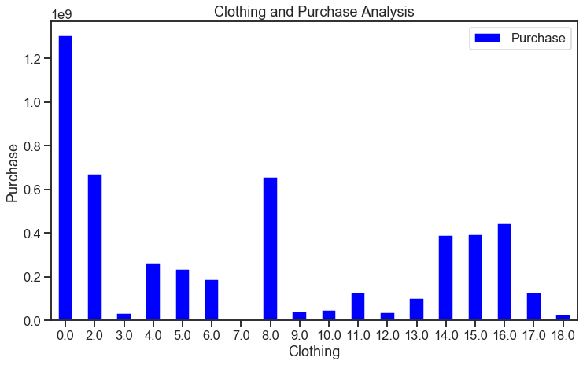

```python
Clothing_pivot = \
d.pivot_table(index='Clothing', values="Purchase", aggfunc=np.sum)

Clothing_pivot.plot(kind='bar', color='blue',figsize=(12,7))
plt.xlabel("Clothing")
plt.ylabel("Purchase")
plt.title("Clothing and Purchase Analysis")
plt.xticks(rotation=0)
plt.show()
```

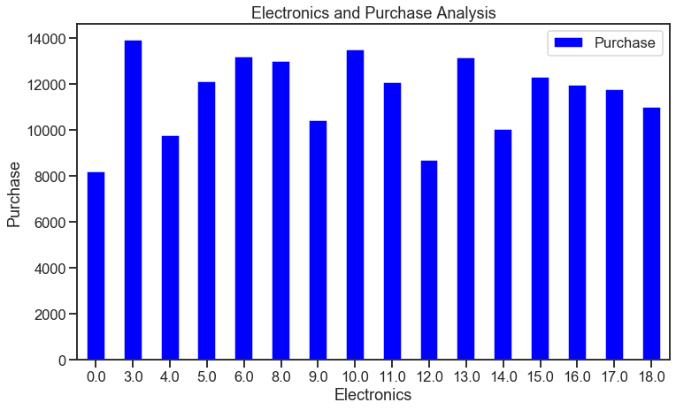

```python
Electronics_pivot = \
d.pivot_table(index='Electronics', values="Purchase", aggfunc=np.mean)

Electronics_pivot.plot(kind='bar', color='blue',figsize=(12,7))
plt.xlabel("Electronics")
plt.ylabel("Purchase")
plt.title("Electronics and Purchase Analysis")
plt.xticks(rotation=0)
plt.show()
```

```python
numeric_features = d.select_dtypes(include=[np.number])
numeric_features.dtypes
```

```
User_ID          int64
Occupation       int64
Furniture        int64
Clothing       float64
Electronics    float64
Purchase         int64
dtype: object
```

**Correlation between numeric predictors and target variable**

```python
corr = numeric_features.corr()

print (corr['Purchase'].sort_values(ascending=False)[:10], '\n')
```

```
Purchase       1.000000
Electronics    0.288501
Clothing       0.052288
Occupation     0.020833
User_ID        0.004716
Furniture     -0.343703
Name: Purchase, dtype: float64
```

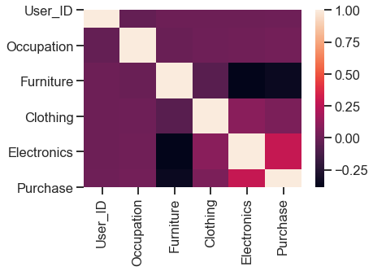

```python
#correlation matrix
tc = d.corr()
sns.heatmap(tc)
```

```python
#Correlations Between Attributes
#Pearson’s Correlation
#Coefficient, that assumes a normal distribution of the attributes involved"""

s = corr.unstack()

s
```

```
User_ID      User_ID        1.000000
             Occupation    -0.023971
             Furniture      0.003825
             Clothing       0.003896
             Electronics    0.003605
             Purchase       0.004716
Occupation   User_ID       -0.023971
             Occupation     1.000000
             Furniture     -0.007618
             Clothing       0.006712
             Electronics    0.012269
             Purchase       0.020833
Furniture    User_ID        0.003825
             Occupation    -0.007618
             Furniture      1.000000
             Clothing      -0.067877
             Electronics   -0.385534
             Purchase      -0.343703
Clothing     User_ID        0.003896
             Occupation     0.006712
             Furniture     -0.067877
             Clothing       1.000000
             Electronics    0.094750
             Purchase       0.052288
Electronics  User_ID        0.003605
             Occupation     0.012269
             Furniture     -0.385534
             Clothing       0.094750
             Electronics    1.000000
             Purchase       0.288501
Purchase     User_ID        0.004716
             Occupation     0.020833
             Furniture     -0.343703
             Clothing       0.052288
             Electronics    0.288501
             Purchase       1.000000
dtype: float64
```

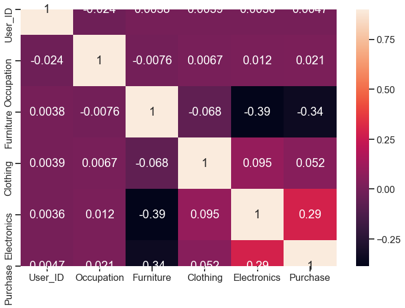

```python
#correlation matrix
f, ax = plt.subplots(figsize=(12, 8))
sns.heatmap(corr, vmax=.9,annot_kws={'size': 20}, annot=True);
```

There seems to be no multicollinearity with our predictors which is a good thing, although there is some correlation among the product categories.

## DATA PREPROCESSING

```python
# Join Train and Test Dataset
d['source']='train'
test['source']='test'

data = pd.concat([d,test], ignore_index = True, sort = False)

print(d.shape, test.shape, data.shape)
```

```
(550068, 14) (233599, 12) (783667, 14)
```

```python
#Check the percentage of null values per variable
data.isnull().sum()/data.shape[0]*100
```

```
User_ID                        0.000000
Product_ID                     0.000000
Gender                         0.000000
Age                            0.000000
Occupation                     0.000000
State                          0.000000
Stay_In_Current_City_Years     0.000000
Marital_Status                 0.000000
Furniture                      0.000000
Clothing                       9.231472
Electronics                   20.743760
Purchase                      29.808452
Gender_MaritalStatus          29.808452
source                         0.000000
dtype: float64
```

```python
data["Clothing"]= \
data["Clothing"].fillna(-2.0).astype("float")
```

```python
data.Clothing.value_counts().sort_index()
```

```
-2.0      72344
 0.0     173638
 2.0      70498
 3.0       4123
 4.0      36705
 5.0      37165
 6.0      23575
 7.0        854
 8.0      91317
 9.0       8177
 10.0      4420
 11.0     20230
 12.0      7801
 13.0     15054
 14.0     78834
 15.0     54114
 16.0     61687
 17.0     19104
 18.0      4027
Name: Clothing, dtype: int64
```

```python
data["Electronics"]= \
data["Electronics"].fillna(-2.0).astype("float")
```

```python
data.Electronics.value_counts().sort_index()
```

```
-2.0     162562
 0.0     383247
 3.0        878
 4.0       2691
 5.0      23799
 6.0       6888
 8.0      17861
 9.0      16532
 10.0      2501
 11.0      2585
 12.0     13115
 13.0      7849
 14.0     26283
 15.0     39968
 16.0     46469
 17.0     23818
 18.0      6621
Name: Electronics, dtype: int64
```

```python
data.shape
```

```
(783667, 14)
```

```python
#Get index of all columns with product_category_1 equal 19 or 20 from train
condition = data.index[(data.Furniture.isin([19,20])) & (data.source == "train")]
data = data.drop(condition)
```

```python
data.shape
```

```
(779514, 14)
```

```python
#Apply function len(unique()) to every data variable
data.apply(lambda x: len(x.unique()))
```

```
User_ID                        5891
Product_ID                     3672
Gender                            2
Age                               7
Occupation                       21
State                             3
Stay_In_Current_City_Years        5
Marital_Status                    2
Furniture                        18
Clothing                         19
Electronics                      17
Purchase                      17996
Gender_MaritalStatus              5
source                            2
dtype: int64
```

## Feature Engineering

**Converting gender to binary**

```python
#Turn gender binary
gender_dict = {'F':0, 'M':1}
data["Gender"] = data["Gender"].apply(lambda line: gender_dict[line])

data["Gender"].value_counts()
```

```
0    587052
1    192462
Name: Gender, dtype: int64
```

**Converting Marital_Status to Binary**

```python
marital_dict = {'Single':0, 'Married':1}
data["Marital_Status"] = data["Marital_Status"].apply(lambda line: marital_dict[line])

data["Marital_Status"].value_counts()
```

```
0    460112
1    319402
Name: Marital_Status, dtype: int64
```

**Converting Age to numeric values**

```python
# Giving Age Numerical values
age_dict = {'0-17':0, '18-25':1, '26-35':2, '36-45':3, '46-50':4, '51-55':5, '55+':6}
data["Age"] = data["Age"].apply(lambda line: age_dict[line])

data["Age"].value_counts()
```

```
2    311554
3    155898
1    141209
4     64902
5     54450
6     30316
0     21185
Name: Age, dtype: int64
```

```python
city_dict = {'NJ':0, 'NYC':1, 'CA':2}
data["State"] = data["State"].apply(lambda line: city_dict[line])

data["State"].value_counts()
```

```
1    328524
2    241487
0    209503
Name: State, dtype: int64
```

**Converting Stay_In_Current_City_Years to binary**

```python
#Import library:
from sklearn.preprocessing import LabelEncoder
le = LabelEncoder()

#New variable for outlet
data['Stay_In_Current_City_Years'] = le.fit_transform(data['Stay_In_Current_City_Years'])

#Dummy Variables:
data = pd.get_dummies(data, columns=['Stay_In_Current_City_Years'])

data.dtypes
```

```
User_ID                           int64
Product_ID                       object
Gender                            int64
Age                               int64
Occupation                        int64
State                             int64
Marital_Status                    int64
Furniture                         int64
Clothing                        float64
Electronics                     float64
Purchase                        float64
Gender_MaritalStatus             object
source                           object
Stay_In_Current_City_Years_0      uint8
Stay_In_Current_City_Years_1      uint8
Stay_In_Current_City_Years_2      uint8
Stay_In_Current_City_Years_3      uint8
Stay_In_Current_City_Years_4      uint8
dtype: object
```

**Function to create count features**

```python
# feature representing the count of each user
def getCountVar(compute_df, count_df, var_name):
    grouped_df = count_df.groupby(var_name)
    count_dict = {}
    for name, group in grouped_df:
        count_dict[name] = group.shape[0]

    count_list = []
    for index, row in compute_df.iterrows():
        name = row[var_name]
        count_list.append(count_dict.get(name, 0))
    return count_list
```

**Exporting Data**

```python
import warnings
warnings.filterwarnings("ignore")
#Divide into test and train:
train = data.loc[data['source']=="train"]
test = data.loc[data['source']=="test"]

#Drop unnecessary columns:
test.drop(['source'],axis=1,inplace=True)
train.drop(['source'],axis=1,inplace=True)

#Export files as modified versions:
#train.to_csv("train_modified.csv",index=False)
#test.to_csv("test_modified.csv",index=False)
```

## MODEL

### Select a Performance Measure

Usually for regression problems the typical performance measure is the Root Mean Square Error (RMSE). This function gives an idea of how much error the system makes in its predictions with higher weight for large errors.

```python
train_df = pd.read_csv('train_modified.csv')
test_df = pd.read_csv('test_modified.csv')
```

```python
train_df.head()
```

|  | User_ID | Product_ID | Gender | Age | Occupation | State | Marital_Status | Furniture | Clothing | Electronics | Purchase | Stay_In_Current_City_Years_0 | Stay_In_Current_City_Years_1 | Stay_In_Current_City_Years_2 | Stay_In_Current_City_Years_3 | Stay_In_Current_City_Years_4 |
| --- | --- | --- | --- | --- | --- | --- | --- | --- | --- | --- | --- | --- | --- | --- | --- | --- |
| 0 | 1000001 | P00069042 | 1 | 0 | 10 | 0 | 0 | 3 | 0 | 0 | 8370 | 0 | 0 | 1 | 0 | 0 |
| 1 | 1000001 | P00248942 | 1 | 0 | 10 | 0 | 0 | 1 | 6 | 14 | 15200 | 0 | 0 | 1 | 0 | 0 |
| 2 | 1000001 | P00087842 | 1 | 0 | 10 | 0 | 0 | 12 | 0 | 0 | 1422 | 0 | 0 | 1 | 0 | 0 |
| 3 | 1000001 | P00085442 | 1 | 0 | 10 | 0 | 0 | 12 | 14 | 0 | 1057 | 0 | 0 | 1 | 0 | 0 |
| 4 | 1000002 | P00285442 | 0 | 6 | 16 | 2 | 0 | 8 | 0 | 0 | 7969 | 0 | 0 | 0 | 0 | 1 |

Since, we’ll be using many model, instead of defining function again and again, we well define a generic function which takes the algorithm and data as input and perform cross-validation and generate submission.

```python
#Define target and ID columns:
target = 'Purchase'
IDcol = ['User_ID','Product_ID']
from sklearn.model_selection import cross_validate,cross_val_score
from sklearn import metrics


def modelfit(alg, dtrain, dtest, predictors, target, IDcol, filename):
    #Fit the algorithm on the data
    alg.fit(dtrain[predictors], dtrain[target])

    #Predict training set:
    dtrain_predictions = alg.predict(dtrain[predictors])

    #Perform cross-validation:
    cv_score = cross_val_score(alg, dtrain[predictors],(dtrain[target]) , cv=20, scoring='neg_mean_squared_error')
    cv_score = np.sqrt(np.abs(cv_score))




    #Print model report:
    print("\nModel Report")
    print("RMSE : %.4g" % np.sqrt(metrics.mean_squared_error((dtrain[target]).values, dtrain_predictions)))
    print("CV Score : Mean - %.4g | Std - %.4g | Min - %.4g | Max - %.4g" % (np.mean(cv_score),np.std(cv_score),np.min(cv_score),np.max(cv_score)))

    #Predict on testing data:
    dtest[target] = alg.predict(dtest[predictors])

    #Export submission file:
    IDcol.append(target)
    submission = pd.DataFrame({ x: dtest[x] for x in IDcol})
    submission.to_csv(filename, index=False)
```

**Linear Regression Model**

```python
from sklearn.linear_model import LinearRegression

LR = LinearRegression(normalize=True)
predictors = train_df.columns.drop(['Purchase','Product_ID','User_ID'])
modelfit(LR, train_df, test_df, predictors, target, IDcol, 'LR.csv')
```

```
Model Report
RMSE : 4631
CV Score : Mean - 4631 | Std - 31.33 | Min - 4573 | Max - 4687
```

**Ridge Regression Model**

```python
from sklearn.linear_model import Ridge
RR = Ridge(alpha=0.05,normalize=True)
modelfit(RR, train_df, test_df, predictors, target, IDcol, 'RR.csv')
```

```
Model Report
RMSE : 4631
CV Score : Mean - 4631 | Std - 31.01 | Min - 4572 | Max - 4686
```

**Decision Tree Regression Model**

```python
from sklearn.tree import DecisionTreeRegressor
DT = DecisionTreeRegressor(max_depth=15, min_samples_leaf=100)
modelfit(DT, train_df, test_df, predictors, target, IDcol, 'DT.csv')
```

```
Model Report
RMSE : 2914
CV Score : Mean - 2941 | Std - 20.86 | Min - 2907 | Max - 2975
```

```python
RF = DecisionTreeRegressor(max_depth=8, min_samples_leaf=150)
modelfit(RF, train_df, test_df, predictors, target, IDcol, 'RF.csv')
```

```
Model Report
RMSE : 2978
CV Score : Mean - 2981 | Std - 20.89 | Min - 2945 | Max - 3021
```

## CONCLUSION

**The Regression model that perform the best was Decision Tree Model with RMSE value of 2914 .So this will be the best fit to predict future sales and purchase for the Black Friday Sale.**

## CITATIONS

1) https://www.kaggle.com/sdolezel/black-friday

2) https://seaborn.pydata.org/

3) https://python-graph-gallery.com/

4) https://towardsdatascience.com/simple-and-multiple-linear-regression-in-python-c928425168f9

5) https://www.geeksforgeeks.org/python-decision-tree-regression-using-sklearn/